# X1 - Decision Trees slides

## Recap: Decision Trees

- Representation: Assume we can represent the concept we want to learn with a *decision tree*
  - Repeatedly split the data based on one feature at a time
  - Note: *Oblique trees* can split on combinations of features
- Evaluation (loss): One tree is better that another tree according to some heuristic
  - Classification: Instances in a leaf are all of the same class (`pure` leafs)
  - Regression: Instances in a leaf have values close to each other
- Optimization: Recursive, heuristic greedy search (Hunt's algorithm)
  - Make first split based on the heuristic
  - In each branch, repeat splitting in the same way

### Decision Tree classification

Where would you make the first split?

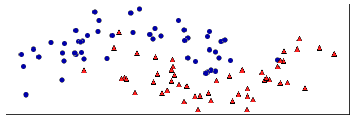

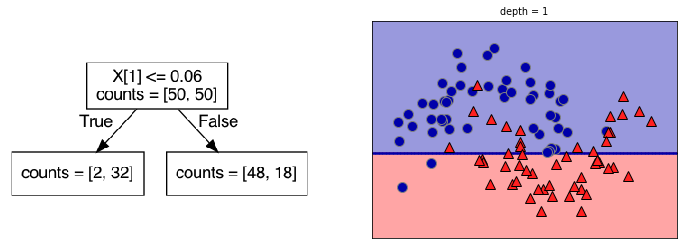

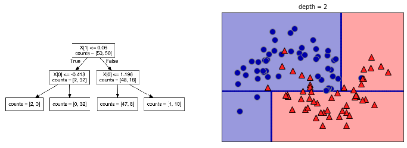

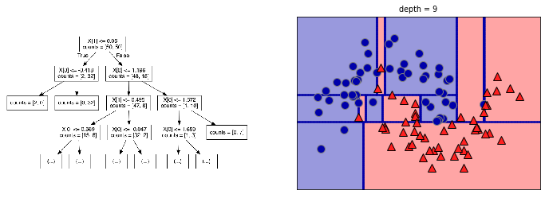

### Heuristics

- We start from a dataset of $n$ points $D = \{(x_i,y_i)\}_{i=1}^{n}$ where $y_i$ is one of $k$ classes
- Consider splits between adjacent data point of different class, for every variable
- After splitting, each leaf will have $\hat{p}_k$ = the relative frequency of class $k$

We can define several *impurity measures*z:

- Misclassification Error (leads to larger trees): $ 1 - \underset{k}{\operatorname{argmax}} \hat{p}_{k} $
- Gini-Index: $ \sum_{k\neq k'} \hat{p}_k \hat{p}_{k'} = \sum_{k=1}^K \hat{p}_k(1-\hat{p}_k) $
- Sum up the heuristics per leaf, weighted by the number of examples in each leaf

$$ \sum_{l=1}^L \frac{|X_{i=l}|}{|X_{i}|} Gini(X_{i=l}) $$

Visualization: the plots on the right show the class distribution of the 'top' and 'bottom' leaf, respectively.

```
interactive(children=(FloatSlider(value=0.5, description='split', max=1.5, min=-0.5, step=0.05), Output()), _d…
```

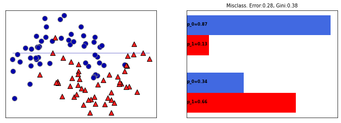

- Entropy (of the class attribute) measures *unpredictability* of the data:
  - How likely will random example have class k? $$ E(X) = -\sum_{k=1}^K \hat{p}_k \log_{2}\hat{p}_k $$
- Information Gain (a.k.a. Kullback–Leibler divergence) measures how much entropy has reduced by splitting on attribute $X_i$: $$ G(X,X_i) = E(X) - \sum_{l=1}^L \frac{|X_{i=l}|}{|X_{i}|} E(X_{i=l}) $$

with $X$ = the training set, $l$ a specific leaf after splitting on feature $X_i$, $X_{i=l}$ is the set of examples in leaf $l$: $\{x \in X | X_i \in l\}$

Heuristics visualized (binary class)

- Note that `gini != entropy/2`

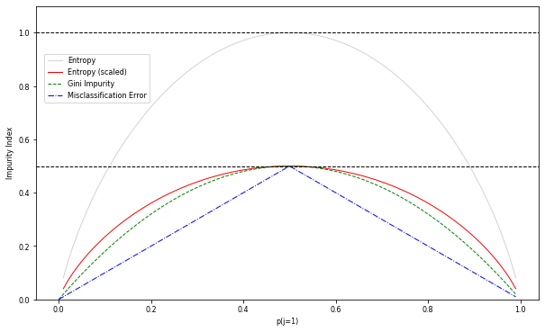

### Example

Compute information gain for a dataset with categorical features:

| Ex. | 1 | 2 | 3 | 4 | 5 | 6 |
| --- | --- | --- | --- | --- | --- | --- |
| a1 | T | T | T | F | F | F |
| a2 | T | T | F | F | T | T |
| class | + | + | - | + | - | - |

$$E(X)?$$$$G(X,X_{a2})?$$$$G(X,X_{a1})?$$

| Ex. | 1 | 2 | 3 | 4 | 5 | 6 |
| --- | --- | --- | --- | --- | --- | --- |
| a1 | T | T | T | F | F | F |
| a2 | T | T | F | F | T | T |
| class | + | + | - | + | - | - |

$E(X)$ = $-(\frac{1}{2}*log_2(\frac{1}{2})+\frac{1}{2}*log_2(\frac{1}{2})) = 1$ (classes have equal probabilities)  
$G(X, X_{a2})$ = 0 (after split, classes still have equal probabilities, entropy stays 1)

| Ex. | 1 | 2 | 3 | 4 | 5 | 6 |
| --- | --- | --- | --- | --- | --- | --- |
| a1 | T | T | T | F | F | F |
| a2 | T | T | F | F | T | T |
| class | + | + | - | + | - | - |

$$ E(X) = -\sum_{k=1}^K \hat{p}_k \log\hat{p}_k \quad , \quad G(X,X_i) = E(X) - \sum_{v=1}^V \frac{|X_{i=v}|}{|X_{i}|} E(X_{i=v}) $$$$E(X_{a1=T}) = - \frac{2}{3} \log_{2}(\frac{2}{3}) - \frac{1}{3} \log_{2}(\frac{1}{3}) = 0.9183 \quad (= E(X_{a1=F}))$$$$G(X, X_{a1}) = 1 - \frac{1}{2} 0.9183 - \frac{1}{2} 0.9183 = 0.0817 $$

hence we split on a1

#### Heuristics in scikit-learn

The splitting criterion can be set with the `criterion` option in `DecisionTreeClassifier`

- `gini` (default): gini impurity index
- `entropy`: information gain

Best value depends on dataset, as well as other hyperparameters

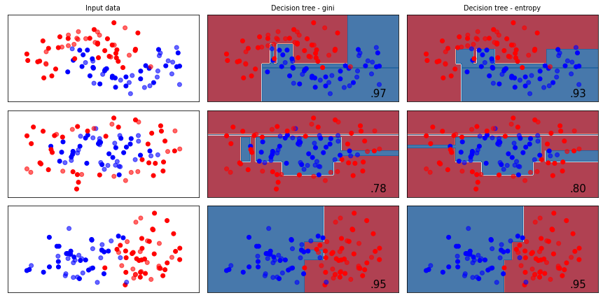

### Handling many-valued features

What happens when a categorical feature has (almost) as many values as examples?

- Information Gain will select it

One approach: use Gain Ratio instead (not available scikit-learn): $$ GainRatio(X,X_i) = \frac{Gain(X,X_i)}{SplitInfo(X,X_i)}$$
$$ SplitInfo(X,X_i) = - \sum_{v=1}^V \frac{|X_{i=v}|}{|X|} log_{2} \frac{|X_{i=v}|}{|X|} $$

where $X_{i=v}$ is the subset of examples for which feature $X_i$ has value v.

SplitInfo will be big if $X_i$ fragments the data into many small subsets, resulting in a smaller Gain Ratio.

### Overfitting: Controlling complexity of Decision Trees

Decision trees can very easily overfit the data. Regularization strategies:

- Pre-pruning: stop creation of new leafs at some point
  - Limiting the depth of the tree, or the number of leafs
  - Requiring a minimal leaf size (number of instances) to allow a split
- Post-pruning: build full tree, then prune (join) leafs
  - Reduced error pruning: evaluate against held-out data
  - Many other strategies exist.
  - scikit-learn supports none of them (yet)

Effect of pre-pruning:

- Shallow trees tend to underfit (high bias)
- Deep trees tend to overfit (high variance)

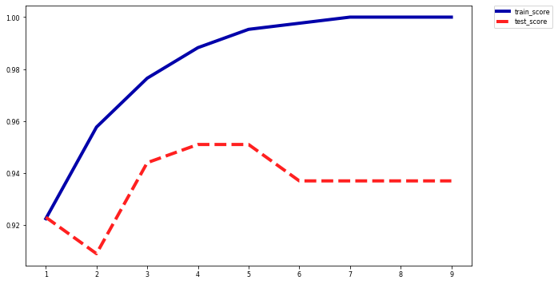

Decision Trees are easy to interpet

- Visualize and find the path that most data takes

[figure not shown]

`DecisionTreeClassifier` also returns *feature importances*

```
tree.feature_importances_
```

- In [0,1], sum up to 1
- High values for features selected early (near the root)

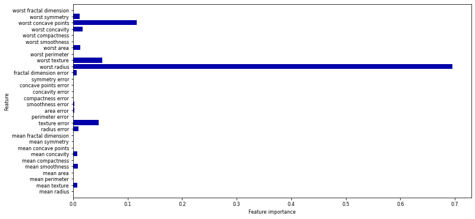

### Decision tree regression

- Heuristic: *Minimal quadratic distance*
- Consider splits at every data point for every variable (or halfway between)
- Dividing the data on $X_j$ at splitpoint $s$ leads to the following half-spaces:

$$ R_1(j, s) = { X : X_j \leq s} \quad and \quad R_2(j, s) = { X : X_j > s} $$

- The best split, with predicted value $c_i$ (mean of all values in the leaf) and actual value $y_i$:

$$ \min_{j,s} \left(\min_{c_1} \sum_{x_{i} \in R_1(j,s)} (y_i - c_1)^2 + \min_{c_2} \sum_{x_{i} \in R_2(j,s)} (y_i - c_2)^2 \right) $$

- Assuming that the tree predicts $y_i$ as the average of all $x_i$ in the leaf:

$$ \hat{c}_1 = \text{avg}(y_i | x_{i} \in R_1(j,s)) \quad and \quad \hat{c}_2 = \text{avg}(y_i | x_{i} \in R_2(j,s)) $$

with $x_i$ being the i-th example in the data, with target value $y_i$

#### In scikit-learn

Regression is done with `DecisionTreeRegressor`

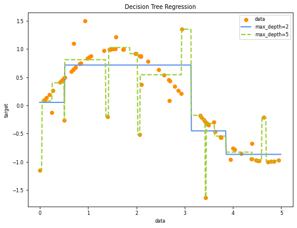

Note that decision trees do not extrapolate well.

- The leafs return the same *mean* value no matter how far the new data point lies from the training examples.
- Example on the `ram_price` forecasting dataset

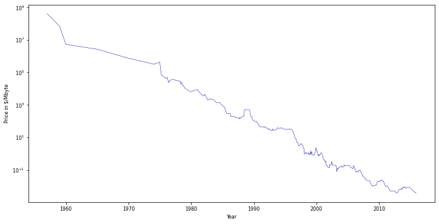

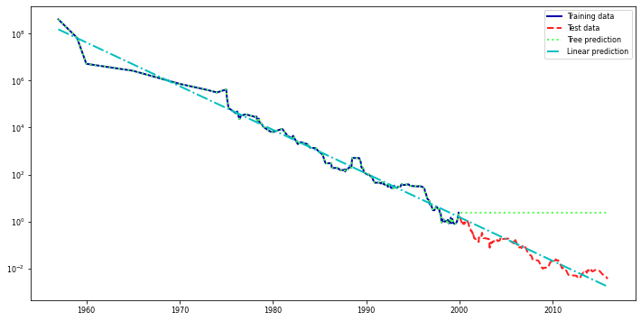

### Model trees

- Instead of predicting a single value per leaf (e.g. mean value for regression), you can build a model on all the points remaining in a leaf
  - E.g. a linear regression model
- Can learn more complex concepts, extrapolates better. Overfits easily.

[figure not shown]

#### Strengths, weaknesses and parameters

Decision trees:

- Work well with features on completely different scales, or a mix of binary and continuous features
  - Does not require normalization
- Interpretable, easily visualized
- Tend to overfit easily.

Pre-pruning: regularize by:

- Setting a low `max_depth`, `max_leaf_nodes`
- Setting a higher `min_samples_leaf` (default=1)

## On under- and overfitting

- Let's study which types of errors are made by decision trees
- Deep trees have high variance but low bias
  - What if we built many deep trees and average them out to reduce variance?
- Shallow trees have high bias but very low variance
  - What if we could correct the systematic mistakes to reduce bias?

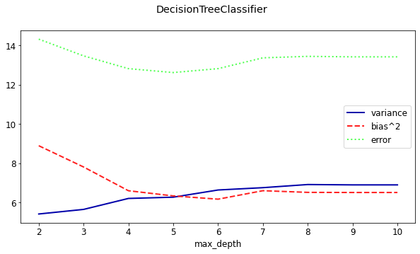

### Algorithm overview

| Name | Representation | Loss function | Optimization | Regularization |
| --- | --- | --- | --- | --- |
| Classification trees | Decision tree | Information Gain (KL div.) / Gini index | Hunt's algorithm | Tree depth,... |
| Regression trees | Decision tree | Min. quadratic distance | Hunt's algorithm | Tree depth,... |
| Model trees | Decision tree + other models in leafs | As above + used model's loss | Hunt's algorithm + used model's optimization | Tree depth,... |